# DEWSeq Analysis

Thomas Schwarzl and Sudeep Sahadevan

07/10/2020

Sanity check input parameter values

```
## Any decimals given as values for min_count and min_sample parameters will be rounded off to the nearest integer.
```

# 1 eCLIP analysis of RBP

## 1.1 Setup

This is the analysis of **RBP** with  
sampleinfo file: `/home/malong/Repos/dewseq_galaxy/test-data/sample_info.exp.txt`  
countmatrix file: `/home/malong/Repos/dewseq_galaxy/test-data/Rbp_count_matrix.exp.txt` and  
annotation file: `/home/malong/Repos/dewseq_galaxy/test-data/windows.exp.txt`

with the following threshold:

minimum read count per window per sample: `2` number of samples with minimum read count per window: `2`

using the following parameters:  
p-value cut-off: `0.5`  
Log2FoldChange cut-off: `1` use automated method for dispersion estmation: `TRUE`  
use LRT test : `FALSE`  
use overlap correction: `FALSE`  
use IHW for FDR correction: `TRUE`

First, we load the libraries.

```r
requiredPackages <- c('DEWSeq','data.table','IHW','R.utils','tidyverse')
installedPackages <- installed.packages()[,1]
diffPackages <- setdiff(requiredPackages,installedPackages)
if(length(diffPackages)!=0){
  stop('Found missing dependencies! Please install the following package(s): ',paste(diffPackages,collapse = ", "))
}
suppressPackageStartupMessages({
  require(DEWSeq)
  require(tidyverse)
  require(data.table)
  require(IHW)
  require(R.utils)
})
```

## 1.2 Read in data

Here we read in the window counts

```r
WINDOWCOUNTS <- fread(countmatrix_file, sep = "\t",stringsAsFactors = FALSE) %>% as.data.frame()
rownames(WINDOWCOUNTS) <- WINDOWCOUNTS[,1]
WINDOWCOUNTS <- WINDOWCOUNTS[,-1]
```

and the sample info file

```r
SAMPLEINFO <- read.table(sampleinfo_file,sep="\t",stringsAsFactors = FALSE)
if(ncol(SAMPLEINFO)<2){
  stop("sampleinfo_file ",sampleinfo_file," MUST have atleast two columns: first column should be the sample names used in ",countmatrix_file,
       " and second column must be the experiment type: IP or SMI")
}else if(ncol(SAMPLEINFO)>2){
  message("Found ",ncol(SAMPLEINFO)," columns in ",sampleinfo_file," using the first column as sample name and second column as experiment name")
  SAMPLEINFO <- SAMPLEINFO[,c(1,2)]
}
colnames(SAMPLEINFO) <- c("samples","type")
rownames(SAMPLEINFO) <- SAMPLEINFO[,1]
```

Now we make sure that the sampleinfo file contains the column “type” with values “SMI” and “IP” only.

```r
# make sure that SAMPLEINFO rows and WINDOWCOUNTS columns are in same order
commonSamples <- sort(intersect(colnames(WINDOWCOUNTS),rownames(SAMPLEINFO)))
if(length(commonSamples)!=ncol(WINDOWCOUNTS)){
  stop("The number of samples in ",countmatrix_file," and ",sampleinfo_file," do not MATCH!")
}
SAMPLEINFO <- SAMPLEINFO[ commonSamples, ]
WINDOWCOUNTS <- WINDOWCOUNTS[,commonSamples]
# Now make sure that SAMPLEINFO$type contains only "IP" and "SMI"
typeCheck <- setdiff(unique(SAMPLEINFO$type),c("IP","SMI"))
if(length(typeCheck)!=0){
  stop("The second column in ",sampleinfo_file," should contain analysis types: 'IP' or 'SMI' only. Found unknown value(s): ",
       paste(typeCheck,collapse=", "))
}
```

We make sure that only IP and SMI are in the right factor level order

```r
SAMPLEINFO <- SAMPLEINFO %>% mutate(type = factor(type, levels = c("SMI", "IP")))
```

We create the DEWSeq object

```r
ddw <- DESeqDataSetFromSlidingWindows(countData  = WINDOWCOUNTS,
                                      colData    = SAMPLEINFO,
                                      annotObj   = annotation_file,
                                      tidy       = FALSE,
                                      design     = ~type)
```

## 1.3 Prefiltering

```r
# remove all empty windows
keep <- rowSums(counts(ddw)) >= 1
ddw <- ddw[keep,]
```

## 1.4 Estimating size factors

```r
ddw <- estimateSizeFactors(ddw)
sizeFactors(ddw)
```

```
## Rbp_ctrl_rep1  Rbp_exp_rep1  Rbp_exp_rep2
##     0.6299605     1.2599210     1.3867225
```

### 1.4.1 estimate size factors for only protein_coding genes

```r
ddw_mRNAs <- ddw[ rowData(ddw)[,"gene_type"] == "protein_coding", ]
ddw_mRNAs <- estimateSizeFactors(ddw_mRNAs)
```

### 1.4.2 estimate size factors without significant windows

```r
ddw_tmp <- ddw
ddw_tmp <- estimateDispersions(ddw_tmp, fitType = "local", quiet = TRUE)
if(LRT){
  ddw_tmp <- nbinomLRT(ddw_tmp,full = ~type,reduced = ~1)
}else{
  ddw_tmp <- nbinomWaldTest(ddw_tmp)
}

tmp_significant_windows <-
                results(ddw_tmp,
                    contrast = c("type", "IP", "SMI"),
                    tidy = TRUE,
                    filterFun = ihw) %>%
                dplyr::filter(padj < p_value_cutoff) %>%
                .[["row"]]
rm(ddw_tmp)
```

estimate the size factors without the significant windows.

```r
ddw_mRNAs <- ddw_mRNAs[ !rownames(ddw_mRNAs) %in% tmp_significant_windows, ]
ddw_mRNAs <- estimateSizeFactors(ddw_mRNAs)
```

before thresholding:

```r
dim(ddw)
```

```
## [1] 3245    3
```

Now threshold the windows read count table.

```r
keep_exp <-  which(rowSums(counts(ddw)>minCount)>=minSample)
ddw <- ddw[keep_exp,]
```

after thresholding:

```r
dim(ddw)
```

```
## [1] 1008    3
```

assign size factors

```r
sizeFactors(ddw) <- sizeFactors(ddw_mRNAs)
rm( list = c("tmp_significant_windows", "ddw_mRNAs"))
sizeFactors(ddw)
```

```
## Rbp_ctrl_rep1  Rbp_exp_rep1  Rbp_exp_rep2
##     0.6299605     1.2599210     1.3867225
```

## 1.5 Differential window analysis

### 1.5.1 Dispersion estimates

We fit parametric and local fit, and decide the best fit following this [Bioconductor post](https://support.bioconductor.org/p/81094/)

```r
parametric_ddw  <- estimateDispersions(ddw, fitType="parametric")
if(decide_fit){
  local_ddw  <- estimateDispersions(ddw, fitType="local")
}
```

This is the dispersion estimate for parametric fit

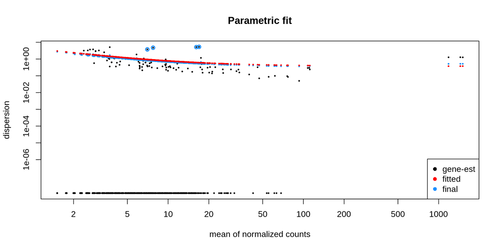

```r
plotDispEsts(parametric_ddw, main="Parametric fit")
```

This is the dispersion estimate for local fit, given automated decision fitting is enabled:

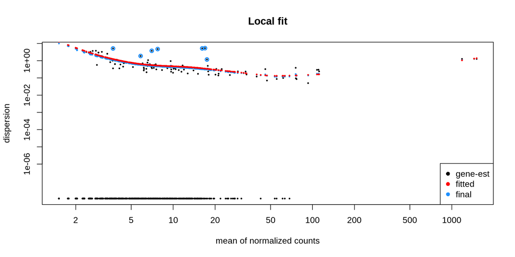

```r
if(decide_fit){
  plotDispEsts(local_ddw, main="Local fit")
}
```

This will get the residuals for either fit, only for automated decision fitting

```r
parametricResid <- na.omit(with(mcols(parametric_ddw),abs(log(dispGeneEst)-log(dispFit))))
if(decide_fit){
  localResid <- na.omit(with(mcols(local_ddw),abs(log(dispGeneEst)-log(dispFit))))
  residDf <- data.frame(residuals=c(parametricResid,localResid),fitType=c(rep("parametric",length(parametricResid)),rep("local",length(localResid))))
  summary(residDf)
}
```

```
##    residuals           fitType
##  Min.   : 0.000899   Length:2016
##  1st Qu.:17.894458   Class :character
##  Median :18.468848   Mode  :character
##  Mean   :16.776221
##  3rd Qu.:18.926598
##  Max.   :20.945520
```

and we plot histograms of the fits

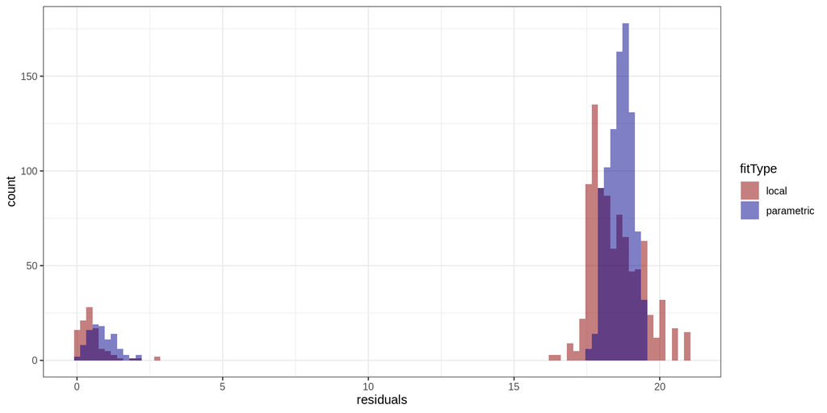

```r
if(decide_fit){
  ggplot(residDf, aes(x = residuals, fill = fitType)) + scale_fill_manual(values = c("darkred", "darkblue")) + geom_histogram(alpha = 0.5, position='identity', bins = 100) + theme_bw()
}
```

Now, we will decide for the better fit based on median

```r
summary(parametricResid)
```

```
##     Min.  1st Qu.   Median     Mean  3rd Qu.     Max.
##  0.09595 18.18429 18.59938 16.85875 18.92660 19.52154
```

```r
if(decide_fit){
  summary(localResid)
  if (median(localResid) <= median(parametricResid)){
    cat("chosen fitType: local")
    ddw <- local_ddw
  }else{
    cat("chosen fitType: parametric")
    ddw <- parametric_ddw
  }
  rm(local_ddw,parametric_ddw,residDf,parametricResid,localResid)
}else{
  ddw <- parametric_ddw
  rm(parametric_ddw)
}
```

```
## chosen fitType: local
```

### 1.5.2 Wald test or LRT

```r
if(LRT){
  ddw <- nbinomLRT(ddw,full = ~type, reduced = ~1)
}else{
  ddw <- nbinomWaldTest(ddw)
}
```

### 1.5.3 Significance testing

```r
resultWindows <- resultsDEWSeq(ddw,
                              contrast = c("type", "IP", "SMI"),
                              tidy = TRUE) %>% as_tibble

resultWindows
```

```
## # A tibble: 672 × 20
##    chromosome   begin   end width strand uniqu…¹ gene_id gene_…² gene_…³ gene_…⁴
##    <chr>        <dbl> <int> <int> <chr>  <chr>   <chr>   <chr>   <chr>   <chr>
##  1 Synechocyst…  2467  2517    50 +      TU5005… TU5005  TU5005  protei… exon
##  2 Synechocyst…  2487  2537    50 +      TU5005… TU5005  TU5005  protei… exon
##  3 Synechocyst…  2507  2557    50 +      TU5005… TU5005  TU5005  protei… exon
##  4 Synechocyst…  2527  2577    50 +      TU5005… TU5005  TU5005  protei… exon
##  5 Synechocyst…  2547  2597    50 +      TU5005… TU5005  TU5005  protei… exon
##  6 Synechocyst…  2567  2617    50 +      TU5005… TU5005  TU5005  protei… exon
##  7 Synechocyst…  2587  2637    50 +      TU5005… TU5005  TU5005  protei… exon
##  8 Synechocyst…  2607  2657    50 +      TU5005… TU5005  TU5005  protei… exon
##  9 Synechocyst…  2627  2677    50 +      TU5005… TU5005  TU5005  protei… exon
## 10 Synechocyst…  2647  2697    50 +      TU5005… TU5005  TU5005  protei… exon
## # … with 662 more rows, 10 more variables: Nr_of_region <int>,
## #   Total_nr_of_region <int>, window_number <int>, baseMean <dbl>,
## #   log2FoldChange <dbl>, lfcSE <dbl>, stat <dbl>, pvalue <dbl>,
## #   pSlidingWindows <dbl>, pSlidingWindows.adj <dbl>, and abbreviated variable
## #   names ¹unique_id, ²gene_name, ³gene_type, ⁴gene_region
```

### 1.5.4 Multiple hypothesis correction with IHW

You might be interested to correct for multiple hypothesis testing with IHW.

Decide on overlap correction based on the parameter `overlap_correction`

```r
if(overlap_correction & IHW){
  resultWindows[,"p_adj_IHW"] <- adj_pvalues(ihw(pSlidingWindows ~ baseMean,
                     data = resultWindows,
                     alpha = p_value_cutoff,
                     nfolds = 10))
  padjCol <- "p_adj_IHW"
}else if(!overlap_correction & IHW){
  resultWindows[,"p_adj_IHW"] <- adj_pvalues(ihw(pvalue ~ baseMean,
                     data = resultWindows,
                     alpha = p_value_cutoff,
                     nfolds = 10))
  padjCol <- "p_adj_IHW"
}else if(overlap_correction & !IHW){
  padjCol <- "pSlidingWindows.adj"
}else{
  resultWindows[,'p_adj'] <- p.adjust(resultWindows$pvalue,method="BH")
  padjCol <- 'p_adj'
}
```

```
## Only 1 bin; IHW reduces to Benjamini Hochberg (uniform weights)
```

Determine significant windows

```r
resultWindows <- resultWindows %>%
                      mutate(significant = resultWindows[ ,padjCol] < p_value_cutoff)
sigWindows <- sum(resultWindows$significant)
```

672 windows are significant

```r
resultWindows %>%
   filter(significant) %>%
   arrange(desc(log2FoldChange)) %>%
   .[["gene_name"]] %>%
   unique %>%
   head(20)
```

```
##  [1] "TU5062" "TU5031" "TU5077" "TU5086" "TU5122" "TU5102" "TU5088" "TU5089"
##  [9] "TU5111" "TU5120" "TU5094" "TU5119" "TU5124" "TU5082" "TU5032" "TU5054"
## [17] "TU5036" "TU5092" "TU5106" "TU5013"
```

### 1.5.5 Combining windows

```r
if(sigWindows>0){
    resultRegions <- extractRegions(windowRes  = resultWindows, padjCol    = padjCol, padjThresh = p_value_cutoff, log2FoldChangeThresh = lfc_cutoff) %>% as_tibble
}
```

### 1.5.6 Writing Bed file

```r
if(sigWindows>1){
    toBED(windowRes = resultWindows, regionRes = resultRegions,padjThresh=p_value_cutoff,
        padjCol   = padjCol, fileName  = output_bed_file)
}else{
  message("This analysis does not have enough <=2 significant windows to create BED file for visualization")
}
```

## 1.6 Save Session

```r
# save enriched windows, gzip results file if the file suffix is .gz
if(grepl("\\.gz$",output_windows_file,ignore.case = TRUE)){
  gz_out <- gzfile(output_windows_file,"w")
  write.table(resultWindows,file=gz_out,sep="\t",quote=FALSE,row.names=FALSE,col.names=TRUE)
  close(gz_out)
}else{
  write.table(resultWindows,file=output_windows_file,sep="\t",quote=FALSE,row.names=FALSE,col.names=TRUE)
}
# save enriched regions
if(sigWindows>0){
  if(grepl("\\.gz$",output_regions_file,ignore.case = TRUE)){
    gz_out <- gzfile(output_regions_file,"w")
    write.table(resultRegions,file=gz_out,sep="\t",quote=FALSE,row.names=FALSE,col.names=TRUE)
    close(gz_out)
  }else{
    write.table(resultRegions,file=output_regions_file,sep="\t",quote=FALSE,row.names=FALSE,col.names=TRUE)
  }
}
# save session
# Warning! session images can be heavy!
if(nchar(output_Rdata)>5){
  save.image( file = output_Rdata)
}
```